# Dynamiques spatio-temporelles des oiseaux communs en Martinique

### 5.26 Solitaire siffleur — Incertain (+20.3% global)

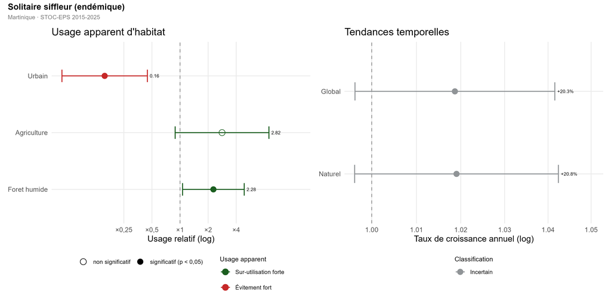

### 5.27 Héron vert — Incertain (-20.1% global)

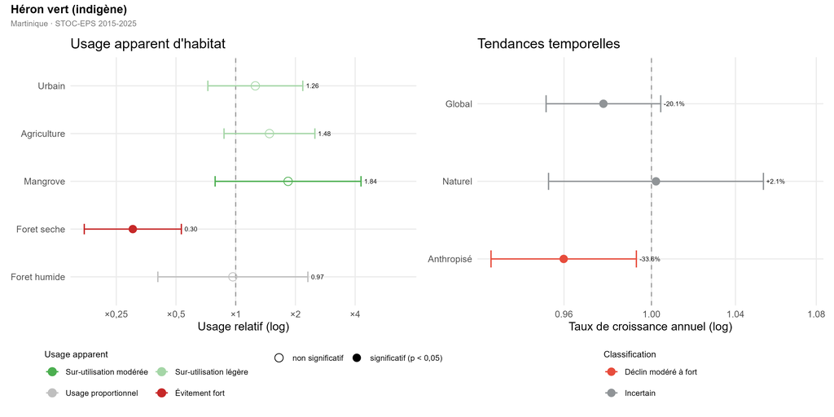

### 5.28 Gallinule d’Amérique — Incertain (-5% global)

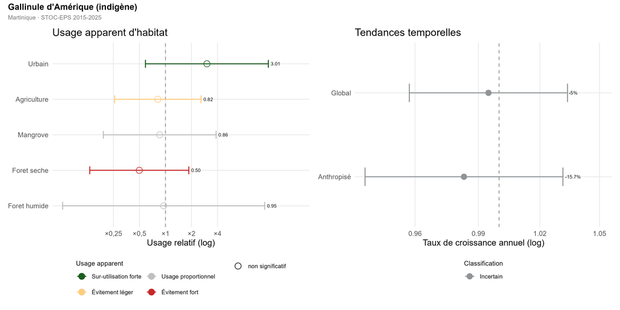

### 5.29 Petite Buse — Incertain (+13.9% global)

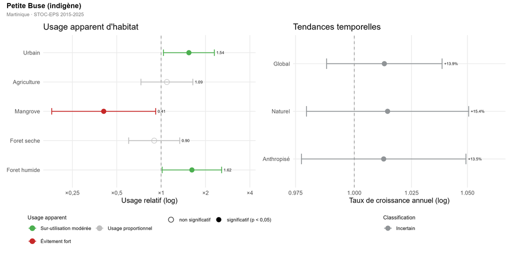

### 5.30 Colombe à queue noire — Incertain (+15.1% global)

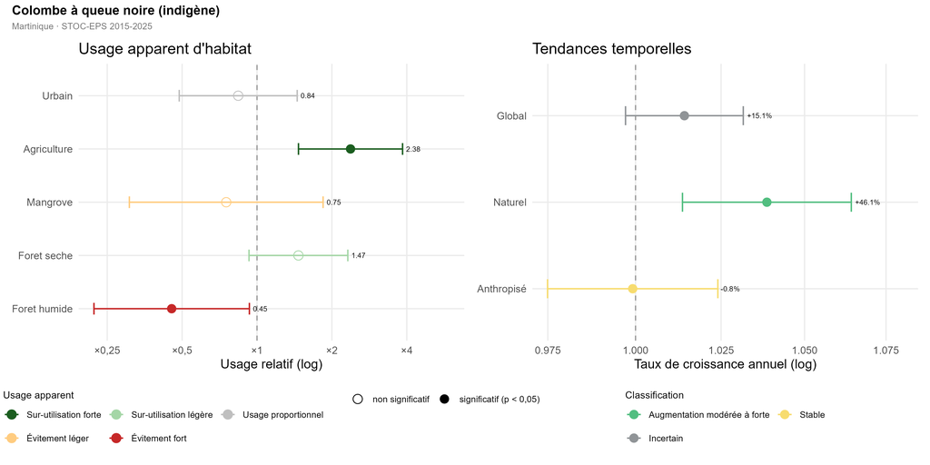

### 5.31 Capucin à tête blanche — Incertain (-44.8% global)

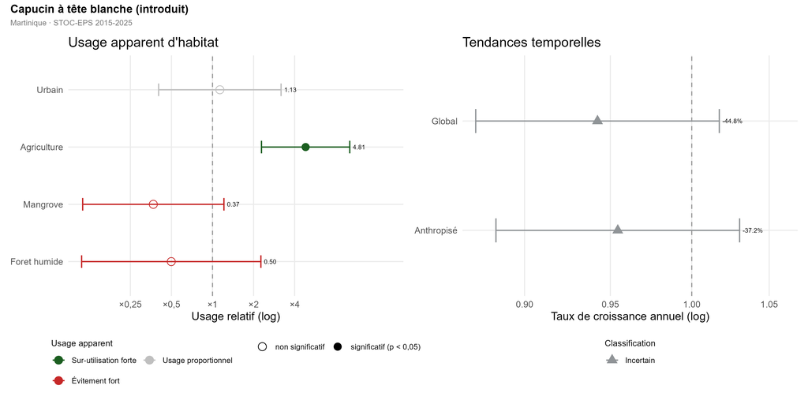

### 5.32 Pigeon biset domestique — Incertain (-31.6% global)

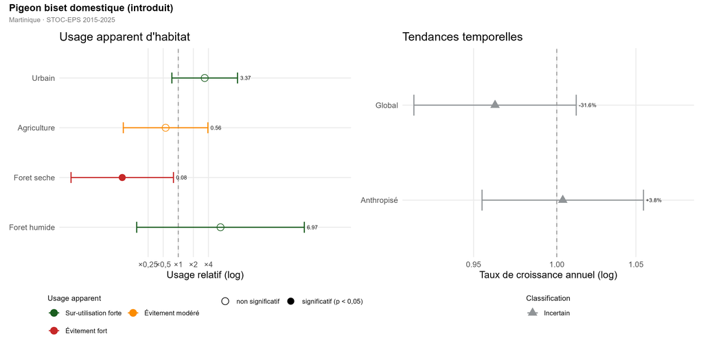

### 5.33 Héron garde-bœuf — Incertain (-16.8% global)

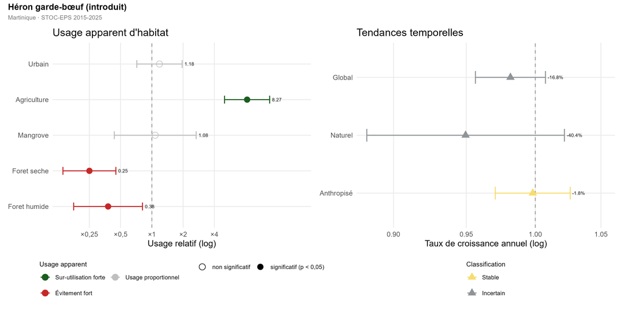

## 6 Espèces écartées de l’analyse d’usage

Espèces exclues de l'analyse d'usage (Objectif 1) et motif

| Espèce | Groupe | Motif |
| --- | --- | --- |
| Coq bankiva | Introduits | 0.1 sites/an < 5 ET 1 hab < 2 |
| Tourterelle oreillarde | Introduits | 0.1 sites/an < 5 ET 1 hab < 2 |
| Astrild cendré | Introduits | 0.2 sites/an < 5 |
| Colombe à croissant | Natifs | 0.2 sites/an < 5 |
| Canard musqué | Introduits | 0.8 sites/an < 5 |
| Perruche à collier | Introduits | 0.9 sites/an < 5 ET 1 hab < 2 |
| Bihoreau gris | Natifs | 1.0 sites/an < 5 |
| Capucin à tête noire | Introduits | 1.5 sites/an < 5 |
| Euplecte franciscain | Introduits | 1.5 sites/an < 5 ET 1 hab < 2 |
| Crécerelle d'Amérique | Natifs | 1.8 sites/an < 5 |
| Tisserin gendarme | Introduits | 1.8 sites/an < 5 |
| Colibri à tête bleue | Natifs | 2.4 sites/an < 5 ET 1 hab < 2 |
| Amazone aourou | Introduits | 2.6 sites/an < 5 ET 1 hab < 2 |
| Moqueur gorge blanche | Natifs | 3.4 sites/an < 5 ET 1 hab < 2 |
| Astrild à joues orange | Introduits | 4.1 sites/an < 5 |
| Organiste louis-d'or | Natifs | 4.4 sites/an < 5 |
| Moqueur corossol | Natifs | 4.5 sites/an < 5 |
| Martinet chiquesol | Natifs | fourrageur aerien - usage non capte au point |
| Sporophile rougegorge | Natifs | retenue mais NB non convergent |

## 7 Conclusion

Sur 2015-2025, les **espèces introduites** sont en **expansion** (+20.5 % global), une hausse **concentrée dans les milieux anthropisés** qu’elles sur-utilisent. Plusieurs colonisatrices (Tourterelle turque, Astrild ondulé, Amazone aourou) progressent fortement.

Les **espèces natives** apparaissent globalement **stables** (-0.9 %), mais ce résultat de groupe **masque le déclin de plusieurs endémiques et espèces forestières** (Moucherolle gobemouche, Sporophile curio, Colibri falle-vert, Moqueurs…), particulièrement en milieu naturel.

**NoteLimites**

- **Indices apparents** : sans correction de détectabilité (2 passages/an agrégés au maximum, pas d’information de distance).
- **Forte hétérogénéité inter-espèces** (I² élevés) : les résultats de groupe résument des espèces contrastées.
- **Espèces grégaires** : les comptages en colonies gonflent la variance (précision optimiste), sans biaiser la direction de l’usage.
- **Mangrove et plage** : milieux littoraux mal capturés par le protocole terrestre ; mangrove gardée distincte pour l’usage, plage exclue de l’usage.
- **Réseau en croissance** (~40 → ~63 sites)
- **Croisement usage ↔︎ tendance** : descriptif, non causal.

### 7.1 Hypothèses

- Expansion des introduits : colonisations récentes en phase active, favorisées par l’anthropisation (agriculture, urbain).
- Déclin des endémiques forestiers : réduction/dégradation des habitats indigènes, compétition, pressions insulaires.